# Class 09: Structural Bioinformatics 1

Lawrence Adhinatha

2023-02-07

# What is in the PDB anyway?

Tha main database of biomolecular structures is called the PDB and is available at www.rcsb.org.

Let’s begin by seeing what is in this database:

```r
stats <- read.csv("Data Export Summary.csv", row.names=1)
stats_df <- as.data.frame(stats)
stats_df
```

```
##                           X.ray    EM    NMR Multiple.methods Neutron Other
## Protein (only)          152,809 9,421 12,117              191      72    32
## Protein/Oligosaccharide   9,008 1,654     32                7       1     0
## Protein/NA                8,061 2,944    281                6       0     0
## Nucleic acid (only)       2,602    77  1,433               12       2     1
## Other                       163     9     31                0       0     0
## Oligosaccharide (only)       11     0      6                1       0     4
##                           Total
## Protein (only)          174,642
## Protein/Oligosaccharide  10,702
## Protein/NA               11,292
## Nucleic acid (only)       4,127
## Other                       203
## Oligosaccharide (only)       22
```

> Q1: What percentage of structures in the PDB are solved by X-Ray and Electron Microscopy.

```r
# delete commas to make values numeric
n.xray <- sum( as.numeric(gsub(",", "", stats_df[,1])))
n.em <- sum( as.numeric(gsub(",", "", stats_df[,2])))
n.total <- sum( as.numeric(gsub(",", "", stats_df[,7])))

# calculate percent to 2 sigfigs
p.stats <- function(num, tot) {
  percent <- round(((num/tot)*100), 2)
  percent
}

p.stats(n.xray, n.total)
```

```
## [1] 85.9
```

```r
p.stats(n.em, n.total)
```

```
## [1] 7.02
```

> Q2: What proportion of structures in the PDB are protein?

```r
n.prot <- sum(as.numeric(gsub(",", "", stats_df[1:3,7])))
p.prot <- p.stats(n.prot, n.total)
p.prot
```

```
## [1] 97.83
```

```r
ind.prot <- (as.numeric(gsub(",", "", stats_df[1:3,7])))
ind.prot/n.total
```

```
## [1] 0.86891755 0.05324696 0.05618246
```

> Q3: Type HIV in the PDB website search box on the home page and determine how many HIV-1 protease structures are in the current PDB?

It is not straightforward to find all HIV-1 protease structures using plain text searching in the database.

# Visualizing the HIV-1 protease structure

A wee pic of HIV-1 Protease from Molstar.

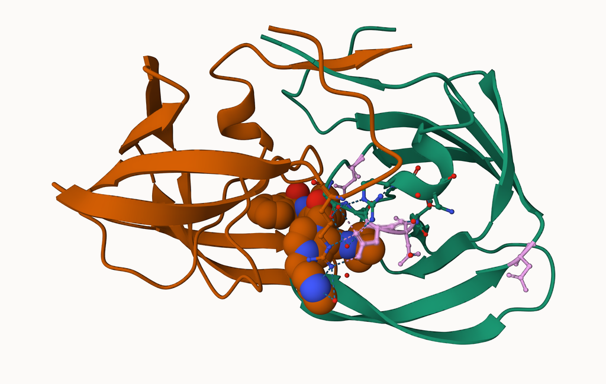

An image obtained from Molstar sufficiently worthy of display for this assignment.

> Q4: Water molecules normally have 3 atoms. Why do we see just one atom per water molecule in this structure?

The resolution of the structure file is 2 Angstroms. A Hydrogen atom is about 1 Angstrom in size, requiring a resolution smaller than that to view it. The atom shown is the Oxygen in the water molecule.

> Q5: There is a critical “conserved” water molecule in the binding site. Can you identify this water molecule? What residue number does this water molecule have

HOH 308

> Q6: Generate and save a figure clearly showing the two distinct chains of HIV-protease along with the ligand. You might also consider showing the catalytic residues ASP 25 in each chain and the critical water (we recommend “Ball & Stick” for these side-chains). Add this figure to your Quarto document. Discussion Topic: Can you think of a way in which indinavir, or even larger ligands and substrates, could enter the binding site?

> Q7: [Optional] As you have hopefully observed HIV protease is a homodimer (i.e. it is composed of two identical chains). With the aid of the graphic display can you identify secondary structure elements that are likely to only form in the dimer rather than the monomer?

# Introduction to Bio3D in R

```r
# Use Bio3D
library(bio3d)
pdb <- read.pdb("1hsg")
```

```
##   Note: Accessing on-line PDB file
```

```r
pdb
```

```
##
##  Call:  read.pdb(file = "1hsg")
##
##    Total Models#: 1
##      Total Atoms#: 1686,  XYZs#: 5058  Chains#: 2  (values: A B)
##
##      Protein Atoms#: 1514  (residues/Calpha atoms#: 198)
##      Nucleic acid Atoms#: 0  (residues/phosphate atoms#: 0)
##
##      Non-protein/nucleic Atoms#: 172  (residues: 128)
##      Non-protein/nucleic resid values: [ HOH (127), MK1 (1) ]
##
##    Protein sequence:
##       PQITLWQRPLVTIKIGGQLKEALLDTGADDTVLEEMSLPGRWKPKMIGGIGGFIKVRQYD
##       QILIEICGHKAIGTVLVGPTPVNIIGRNLLTQIGCTLNFPQITLWQRPLVTIKIGGQLKE
##       ALLDTGADDTVLEEMSLPGRWKPKMIGGIGGFIKVRQYDQILIEICGHKAIGTVLVGPTP
##       VNIIGRNLLTQIGCTLNF
##
## + attr: atom, xyz, seqres, helix, sheet,
##         calpha, remark, call
```

```r
head(pdb$atom)
```

```
##   type eleno elety  alt resid chain resno insert      x      y     z o     b
## 1 ATOM     1     N <NA>   PRO     A     1   <NA> 29.361 39.686 5.862 1 38.10
## 2 ATOM     2    CA <NA>   PRO     A     1   <NA> 30.307 38.663 5.319 1 40.62
## 3 ATOM     3     C <NA>   PRO     A     1   <NA> 29.760 38.071 4.022 1 42.64
## 4 ATOM     4     O <NA>   PRO     A     1   <NA> 28.600 38.302 3.676 1 43.40
## 5 ATOM     5    CB <NA>   PRO     A     1   <NA> 30.508 37.541 6.342 1 37.87
## 6 ATOM     6    CG <NA>   PRO     A     1   <NA> 29.296 37.591 7.162 1 38.40
##   segid elesy charge
## 1  <NA>     N   <NA>
## 2  <NA>     C   <NA>
## 3  <NA>     C   <NA>
## 4  <NA>     O   <NA>
## 5  <NA>     C   <NA>
## 6  <NA>     C   <NA>
```

What is the first residue 3 letter code?

```r
pdb$atom$resid[1]
```

```
## [1] "PRO"
```

```r
aa321(pdb$atom$resid[1])
```

```
## [1] "P"
```

> Q7: How many amino acid residues are there in this pdb object?

198 aa residues

> Q8: Name one of the two non-protein residues?

HOH

> Q9: How many protein chains are in this structure?

2

```r
attributes(pdb)
```

```
## $names
## [1] "atom"   "xyz"    "seqres" "helix"  "sheet"  "calpha" "remark" "call"
##
## $class
## [1] "pdb" "sse"
```

## Predicting functional motions of a single structure

Let’s read a new PDB structure of Adenylate Kinase (PDB code: 6s36) and perform Normal mode analysis.

```r
adk <- read.pdb("6s36")
```

```
##   Note: Accessing on-line PDB file
##    PDB has ALT records, taking A only, rm.alt=TRUE
```

```r
adk
```

```
##
##  Call:  read.pdb(file = "6s36")
##
##    Total Models#: 1
##      Total Atoms#: 1898,  XYZs#: 5694  Chains#: 1  (values: A)
##
##      Protein Atoms#: 1654  (residues/Calpha atoms#: 214)
##      Nucleic acid Atoms#: 0  (residues/phosphate atoms#: 0)
##
##      Non-protein/nucleic Atoms#: 244  (residues: 244)
##      Non-protein/nucleic resid values: [ CL (3), HOH (238), MG (2), NA (1) ]
##
##    Protein sequence:
##       MRIILLGAPGAGKGTQAQFIMEKYGIPQISTGDMLRAAVKSGSELGKQAKDIMDAGKLVT
##       DELVIALVKERIAQEDCRNGFLLDGFPRTIPQADAMKEAGINVDYVLEFDVPDELIVDKI
##       VGRRVHAPSGRVYHVKFNPPKVEGKDDVTGEELTTRKDDQEETVRKRLVEYHQMTAPLIG
##       YYSKEAEAGNTKYAKVDGTKPVAEVRADLEKILG
##
## + attr: atom, xyz, seqres, helix, sheet,
##         calpha, remark, call
```

Normal mode analysis (NMA) is a structural bioinformatics method to predict protein flexibility and potential functional motions (a.k.a. conformational changes).

```r
m <- nma(adk)
```

```
##  Building Hessian...     Done in 0.021 seconds.
##  Diagonalizing Hessian...    Done in 0.444 seconds.
```

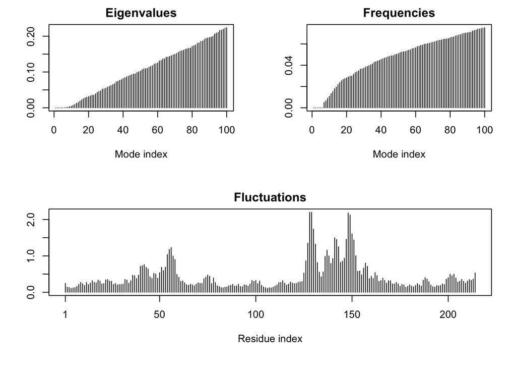

```r
plot(m)
```

```r
mktrj(m, file="adk_m7.pdb")
```

# Comparative structure analysis of Adenylate Kinase

We will now be conducting a Principal Component Analysis on the complete collection of Adenylate kinase structures in the PDB.

We begin with getting a singl eprotein sequence for a protein family of interest.

msa package.

> Q11. Which of the above packages is not found on BioConductor or CRAN?:

bio3d view

> Q12. True or False? Functions from the devtools package can be used to install packages from GitHub and BitBucket?

True

```r
library(bio3d)

aa <- get.seq("1ake_A")
```

```
## Fetching... Please wait. Done.
```

```r
aa
```

```
##              1        .         .         .         .         .         60
## pdb|1AKE|A   MRIILLGAPGAGKGTQAQFIMEKYGIPQISTGDMLRAAVKSGSELGKQAKDIMDAGKLVT
##              1        .         .         .         .         .         60
##
##             61        .         .         .         .         .         120
## pdb|1AKE|A   DELVIALVKERIAQEDCRNGFLLDGFPRTIPQADAMKEAGINVDYVLEFDVPDELIVDRI
##             61        .         .         .         .         .         120
##
##            121        .         .         .         .         .         180
## pdb|1AKE|A   VGRRVHAPSGRVYHVKFNPPKVEGKDDVTGEELTTRKDDQEETVRKRLVEYHQMTAPLIG
##            121        .         .         .         .         .         180
##
##            181        .         .         .   214
## pdb|1AKE|A   YYSKEAEAGNTKYAKVDGTKPVAEVRADLEKILG
##            181        .         .         .   214
##
## Call:
##   read.fasta(file = outfile)
##
## Class:
##   fasta
##
## Alignment dimensions:
##   1 sequence rows; 214 position columns (214 non-gap, 0 gap)
##
## + attr: id, ali, call
```

> Q13. How many amino acids are in this sequence, i.e. how long is this sequence?

214 amino acids long

Now we can use this sequence as a query to BLAST search the PDB to find similar sequences and structures.

```r
# Blast or hmmer search
# b <- blast.pdb(aa)
```

Rather than re-running the BLAST search every time this document loads (and save these results for this point in time), we can save and loadf the blast results.

```r
# saveRDS(b, file="blast_results.RDS")
```

```r
b <- readRDS("blast_results.RDS")
```

A summary plot of our BLAST results

```
##   * Possible cutoff values:    197 -3
##             Yielding Nhits:    16 96
##
##   * Chosen cutoff value of:    197
##             Yielding Nhits:    16
```

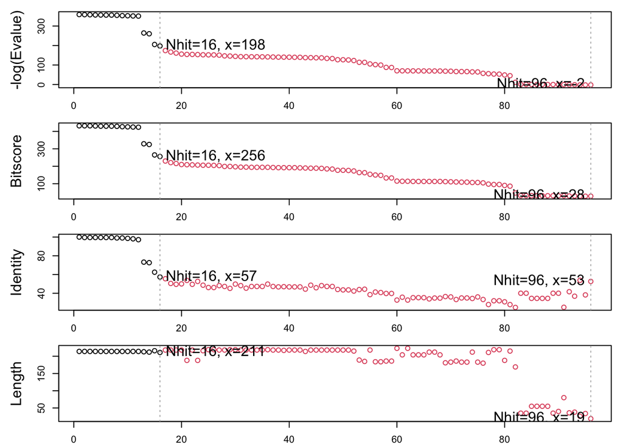

```r
hits <- plot(b)
```

```r
hits
```

```
## $hits
##    pdb.id   acc      group
## 1  "1AKE_A" "1AKE_A" "1"
## 2  "4X8M_A" "4X8M_A" "1"
## 3  "6S36_A" "6S36_A" "1"
## 4  "6RZE_A" "6RZE_A" "1"
## 5  "4X8H_A" "4X8H_A" "1"
## 6  "3HPR_A" "3HPR_A" "1"
## 7  "1E4V_A" "1E4V_A" "1"
## 8  "5EJE_A" "5EJE_A" "1"
## 9  "1E4Y_A" "1E4Y_A" "1"
## 10 "3X2S_A" "3X2S_A" "1"
## 11 "6HAP_A" "6HAP_A" "1"
## 12 "6HAM_A" "6HAM_A" "1"
## 13 "4K46_A" "4K46_A" "1"
```

[output cut: 24 more lines]

```r
hits$pdb.id
```

```
##  [1] "1AKE_A" "4X8M_A" "6S36_A" "6RZE_A" "4X8H_A" "3HPR_A" "1E4V_A" "5EJE_A"
##  [9] "1E4Y_A" "3X2S_A" "6HAP_A" "6HAM_A" "4K46_A" "4NP6_A" "3GMT_A" "4PZL_A"
```

```r
# Download related PDB files
files <- get.pdb(hits$pdb.id, path="pdbs", splot=TRUE, gzip=TRUE)
```